# How Many Confederate Monuments and Other Symbols Are There in the US?

# This map shows how many Confederate monuments and symbols still stand in the US

[Madison Hoff](https://www.businessinsider.com/author/madison-hoff)

Jun 13, 2020, 9:25 AM

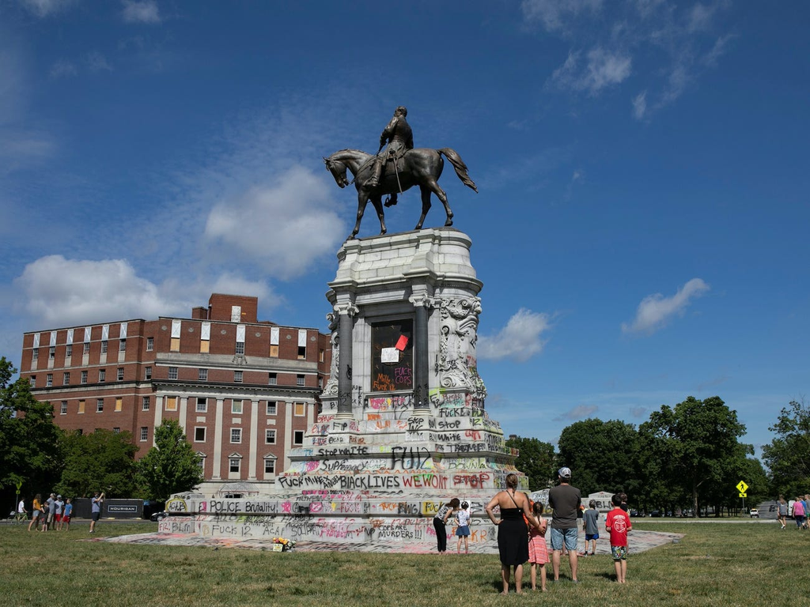

People visit a monument of Confederate general Robert E. Lee after Virginia Governor Ralph Northam ordered its removal after widespread civil unrest following the death in Minneapolis police custody of George Floyd, in Richmond, Virginia, on June 5, 2020.

Julia Rendleman/Reuters

- Mayors and state governors, colleges, and other organizations have already taken down or are considering removing Confederate monuments, banning Confederate flags, and renaming places currently named after Confederate leaders.
- Protesters and other Americans have called for these monuments and symbols to be removed as one way to address racial issues in the US.
- The [Southern Poverty Law Center](https://www.splcenter.org/) shared with Business Insider the number of Confederate symbols in each US state as of June 9.
- As of June 9, there were nearly 1,800 Confederate monuments, statues, and other symbols in the US.
- [Visit Business Insider's homepage for more stories](https://www.businessinsider.com/?hprecirc-bullet).

As protesters push for change in the United States after the death of George Floyd, there are renewed calls for statues and other Confederate monuments to be removed across the country.

Protesters have recently torn down or painted over monuments of Confederate leaders and other colonialist figures. Actions included spray-painting [phrases](https://www.insider.com/anti-racism-protesters-in-us-europe-tear-down-monuments-2020-6) like "Save Black lives" and "We just want justice" on the Robert E. Lee statue in Richmond, Virginia, and beheading the [Christopher Columbus](https://www.businessinsider.com.au/anti-racism-protesters-in-us-europe-tear-down-monuments-2020-6) statue in Boston.

After a 2017 rally by white nationalists, neo-Nazis, and alt-right members turned violent in [Charlottesville, Virginia](https://www.businessinsider.com/how-many-confederate-monuments-in-the-us-charlottesville-2017-8), several local and state officials removed Confederate monuments across the country, such as in [Baltimore](https://www.businessinsider.com/confederate-statue-monument-taken-down-2017-8). Now, in the wake of the current protests, many officials are discussing removing monuments and other symbols that they say demonstrate racism in the US.

Many of the Confederate memorials at issue were created decades after the Civil War that lasted from 1861 to 1865. According to [History.com](https://www.history.com/news/how-the-u-s-got-so-many-confederate-monuments), many were built between the 1890s and 1950s, during the period of Jim Crow laws and particularly harsh repression and segregation of the Black population.

We decided to take a look at how many of those monuments still stand across the country.

Using a variety of [data sets and other resources](https://www.splcenter.org/20190201/whose-heritage-public-symbols-confederacy#methodology), the [Southern Poverty Law Center](https://www.splcenter.org/) records the number of Confederate symbols in the US. In addition to seals, plaques, monuments, and flags, the legal advocacy group also counts the number of buildings, holidays, songs, parks and trails, roads, and schools, and other places that include Confederate symbols and memorialize [Confederate leaders](https://www.businessinsider.com/confederate-monuments-spark-controversy-2017-8).

According to Lecia Brooks, chief workplace transformation officer at the Southern Poverty Law Center, of the nearly 1,800 Confederate symbols in the US as of the morning of June 9, 775 are monuments and statues. The remainder are other symbols like parks, military bases, highway names, and government buildings named after Confederate officials.

This number, however, is rapidly changing in the wake of the current protests, and is likely to decline over the next several weeks.

The following map highlights the number of Confederate symbols in every state as of June 9 according to the Southern Poverty Law Center. The majority of symbols are found in Southern states, especially those that were members of the Confederacy, but there are a few symbols in other parts of the US, such as five in California and two in Montana.

[figure not shown]

Business Insider/Madison Hoff, data from Southern Poverty Law Center

The Southern Poverty Law Center shared with Business Insider two recent instances in Alabama of the removal of Confederate symbols.

The University of Alabama on June 9 decided to remove a Confederate memorial plaque after a swift vote by the board of trustees on June 8, according to [Tuscaloosanews.com](https://www.tuscaloosanews.com/news/20200609/university-of-alabama-removes-confederate-monument).

In Mobile, Alabama, Mayor Sandy Stimpson called for the statue of Confederate Admiral Raphael Semmes to be removed. It was removed last Friday after Stimpson's request on June 4. Stimpson told [AL.com](https://www.al.com/news/2020/06/breaking-mobile-removes-confederate-statue-without-warning-after-days-of-george-floyd-protests.html) in a statement that the removal is not to "rewrite history" but "focus clearly on the future of our city."

Protesters have also pulled down statues themselves in Virginia, as reported by [The Washington Post.](https://www.washingtonpost.com/local/virginia-politics/with-virginias-effort-to-remove-lee-statue-on-hold-protesters-topple-confederate-figures/2020/06/11/4cc88d2a-abf5-11ea-9063-e69bd6520940_story.html) However, Virginia Governor Ralph Northam has urged protesters to stop so that statues can be safely removed by officials. A Confederate monument in Portsmouth, Virginia, that was partially brought down by protesters injured someone, according to local Harrisonburg, Virginia, news station [WHSV](https://www.whsv.com/content/news/Gov-Northam-addressing-Virginia-amid-improving-COVID-stats-spree-of-torn-down-Richmond-statues-571190331.html).

A new law in Virginia will allow local governments to decide what to do with monuments. Northam recently talked about the plan to remove the Robert E. Lee statue in Richmond, Virginia, and Richmond Mayor Levar Stoney said a new ordinance is planned for July 1 that will require all Confederate monuments in the city to be removed, according to [WHSV](https://www.whsv.com/content/news/Richmond-mayor-to-to-introduce-ordinance-to-remove-Confederate-monuments-570998991.html).

In addition to officials considering the removal of public confederate symbols, [NASCAR](https://www.insider.com/nascar-bans-confederate-flag-from-races-latest-racial-equality-effort-2020-6) also recently banned the Confederate flag from its races. The [US Marine Corps](https://www.businessinsider.com/marine-corps-bans-confederate-battle-flag-military-bases-2020-6) similarly banned the Confederate flag. The [US Army](https://www.businessinsider.com/military-bases-named-after-confederate-leaders-2020-6) is considering renaming military bases that are currently named after Confederate officers and generals.

Some officials have voiced opposition to removing the monuments. According to a recent [Time](https://time.com/5849184/confederate-statues-removed/) article, the Virginia Senate Republican Caucus issued a statement saying the removal of Robert E. Lee statue is "not in the best interests of Virginia."